# Homework 6

Jiawei Hao, hjiawei

Due Oct. 12 at midnight

## Question 1 (5 points)

Continuing our use of the Laplace distribution, we will use it as a candidate distribution for the standard Normal $N(0,1)$ distribution using an accept-reject algorithm.

Recall that the probability distribution for a standard Normal is given by:

$$f(x) = \frac{1}{\sqrt{2 \pi}} \exp\left\{ - \frac{x^2}{2} \right\}$$

and the Laplace is given by
$$g(x) = \frac{1}{2} \exp\left\{- |x| \right\}$$

### Part (a) (1 pt)

Analytically (i.e., pen and paper, not computation), find a constant $c$ such that:
$$\frac{c g(x)}{f(x)} \ge 1$$
for all $x \in (-\infty, \infty)$. As we have frequently done, it may be helpful to consider $x < 0$ and $x \ge 0$ separately.

**Answer**: By moving terms, we can get $c \ge \frac{f(x)}{g(x)}$. We then can get $c \ge \frac{2}{\sqrt{2\pi}}e^{-\frac{x^2}{2}+x}$ for $x \ge 0$ and $c \ge \frac{2}{\sqrt{2\pi}}e^{-\frac{x^2}{2}-x}$ for $x < 0$. If we take the derivative of each, we find functions peak at $x=1$ and $x=-1$. Plug these values back in, we got $f(x)=1.315489$ for both since both functions symmetrical at $x=0$. Thus, $c=1.315489$ such that $\frac{c g(x)}{f(x)} \ge 1$.

### Part (b) (2 pt)

Implement an accept-reject algorithm for standard Normals using $c$ and our usual source of Laplace random variables.

```r
rlaplace <- function(n, mean = 0) {
  s <- 2 * rbinom(n, size = 1, p = 0.5) - 1
  m <- rexp(n)
  s * m + mean
}

dplace <- function(n){
  0.5*exp(-abs(n))
}
k <- 10000
c <- 1.315489

dlaplace <- dplace(rlaplace(k))
dnorm <- dnorm(dlaplace)
ratios <- dnorm/(c*dlaplace)

us <- runif(10000)
accept_g <- us < ratios
accepted_g <- dlaplace[accept_g]
```

Using 1000 samples, verify that your Accept-Reject algorithm works using a QQ-plot (see `geom_qq`).

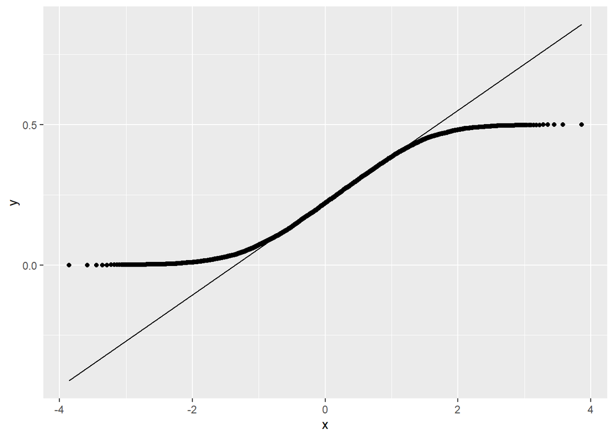

```r
ggplot(data.frame(x = accepted_g),aes(sample = x)) + geom_qq() + geom_qq_line()
```

### Part (c) (2 pt)

Now implement an importance sampling algorithm for standard Normals using the Laplace distribution as the envelope distribution in order to estimate

$$E(X^2)$$
where $X \sim N(0, 1)$. Use 1000 samples and provide a 95% confidence interval for $E(X^2)$.

```r
k1 <- 1000
x_square <- rlaplace(k1)
dlaplace1 <- dplace(rlaplace(k1))
dnorm1 <- dnorm(x_square)
expectation <- mean((x_square)^2*dnorm1/dlaplace1)
t.test(x_square*dnorm1/dlaplace1, conf.level = 0.95)$conf.int
```

```
## [1] -0.269482  0.376222
## attr(,"conf.level")
## [1] 0.95
```

## Question 2 (4 pts)

Consider the density (known up to a constant) given by:

$$f(x) \propto \sin(\pi x^2), \quad 0 < x < 1$$

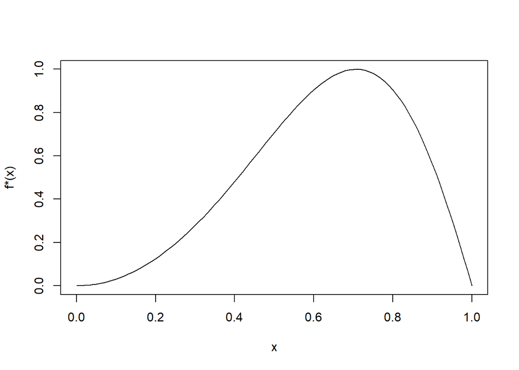

```r
curve(sin(pi * x^2), ylab = "f*(x)")
```

### Part (a) (2 pts)

We want to estimate $E(X)$ using importance sampling (resampling).

Using a uniform [0, 1] distribution as the envelope, use (reweighted) importance sampling to estimate $E(X)$. Estimate the variance of the **estimator** (we’ll compare it to another estimator in part (b)).

### Part (b) (2 pt)

The uniform distribution is a special case of the [Beta distribution](https://en.wikipedia.org/wiki/Beta_distribution) with parameters $\alpha = \beta = 1$. It works as an envelope, but it does not very carefully follow the target function:
$$E(X) \propto \int_0^1 x \sin(\pi x^2) \, dx$$

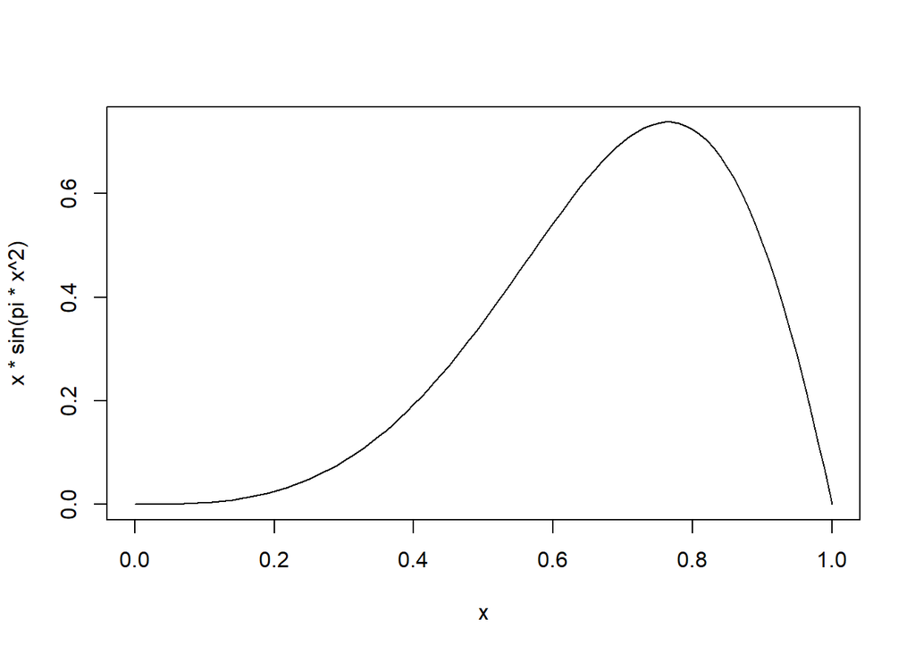

```r
curve(x * sin(pi * x^2))
```

Propose a set of parameters $\alpha$ and $\beta$ that leads to a better envelope distribution. Use this distribution (see the `rbeta` function) to implement importance sampling to estimate $E(X)$ and the variance of the estimator. Did this estimator have lower variance than the estimator based on the uniform candidate?

Useful tip: A Beta($\alpha, \beta$) with $\alpha > 1$ and $\beta > 1$ will have a mode at $(\alpha - 1) / (\alpha + \beta - 2)$. This can be useful to graph candidate distributions against the target:

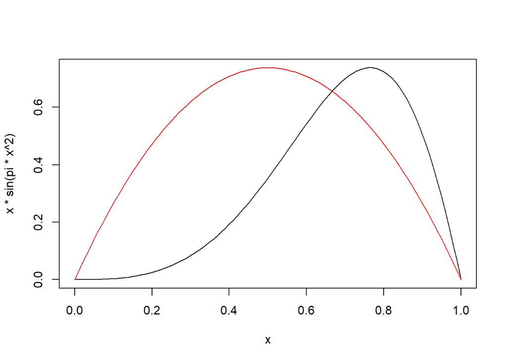

```r
## target function has a mode at approximately 0.76
target_height <- 0.76 * sin(pi * 0.76^2)

## candidate beta distribution alpha = beta = 2, so a mode at 1/2
cand_height <- dbeta(1/2, 2, 2)

tc_ratio <- target_height/cand_height

curve(x * sin(pi * x^2))
curve(tc_ratio * dbeta(x, 2, 2), add = TRUE, col = "red")
```

## Question 3 (1 pts)

It is time to start thinking about research projects. The core research question drives what data are required, what methods are considered, appropriate visualizations, etc.

Do one of the following:

1. Look at the three starter research projects available on Canvas. Pick one project and write a new research question based on the existing paper. It should be motivated by research questions in the paper, but not identical to it. Describe data that would help answer your research question.
2. For a topic of your choice, write a research questions (three to four sentences total). The question should be clearly motivated and include a justification of who would be interested in your research results. Here is an example (unlike the example, you do not need give a specific model at this time, but the more specific the research question the better):

> Political committees in the United States play a significant role in supporting candidates, lobbying for policies, and organizing citizens. Political committees may also support other political committees through monetary contributions. Modeling the structure of these contributions will better help citizens understand the connections between committees and the role of money in politics. In particular, do political committees allocate their contributions to other committees randomly or are the amounts of contributions specifically targeted in some way? Specifically, do contributions follow the well known Benford’s law, a model describing the distribution of leading digits for many natural processes, or do they follow some other systematic pattern?

Write a few sentences describing an ideal data source. What kinds of variables are required? Do you need data collected from a specific location or time? Do you need observations over time or space? Does this data support any other interesting research questions?

> Example: To see if Benford’s law holds, I require data showing how much money political comittees spend on other political committees. I would like to have data over multiple years so I can also compare it to changes in legislation that may result in changes in the amounts of money donated. I would like to have variables describing the political committees such as if they have a lobbying group or are aligned with a particular political party. Since these data describe relationships among committees, this network could also be analyzed to learn about connections between the committees.